# act_report

## Report: act_report

- Create a **250-word-minimum written report** called "act_report.pdf" or "act_report.html" that communicates the insights and displays the visualization(s) produced from your wrangled data. This is to be framed as an external document, like a blog post or magazine article, for example.

### Introduction:

In this project, we gather, assess, and clean data and then act on it by wrangling the data.

- WeRateDogs Twitter archive was downloaded from Ucadity (given to us by downloading it from the classroom)
- Twitter Image Prediction (Image_predictions.tsv) was downloaded programmatically from the URL using the Requests library
- Additional data from Twitter was downloaded using Twitter API (Tweepy) and stored as tweets_data.txt
- Data was then assessed visually and programmatically before being cleaned for exploratory analysis.

### Insight and visualizations from the data

#### Question 1: How many tweets are posted yearly?

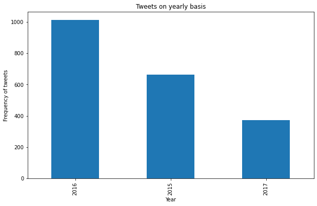

#### Question 2: What kind of devices were the tweets posted from?

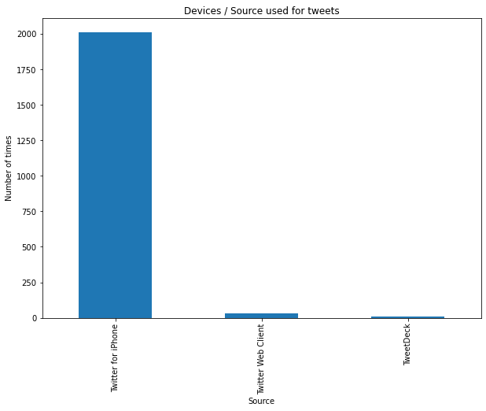

#### From the bar chart, it can be deduced that tweets from Twitter for iPhone were the highest, followed by Twitter web clients and TweetDeck respectively.

Figuratively, sources of tweets from Twitter for iPhone was 2012, followed by Twitter Web Client which also was 30 and tweets from TweetDeck recorded was 10. From the bar chart visiualized based on this figures, it can be deduced that tweets from Twitter for Iphones were the highest, followed by Twitter web clients and TweetDeck respectively.

#### Question 4: What is the nature of tweets daily from 2015 to date?

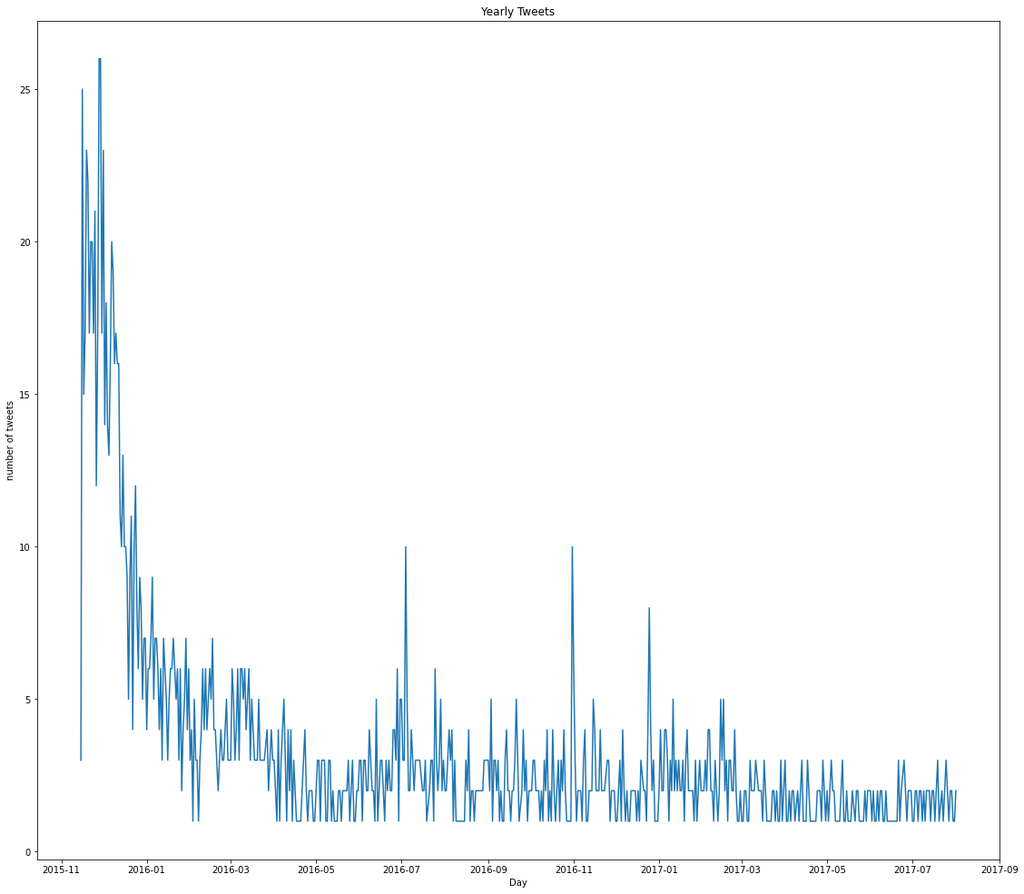

#### From this line chart, it can be deduced that there is a sharp drop in the number of tweets from 2015-11 to 2026-01 and a gradual rise and drop in the tweets from 2016-03 to 2017-09.

The line chart visualized based on the question stated above indicates that there is a sharp drop in the number of tweets from 2015-11 to 2026-01 and a gradual "rise and drop" in the tweets from 2016-03 to 2017-01. It can also be noticed that there were occasional peaks between "2016-05 and 2016-09" and “2016-03 to 2017-09" respectively.

## Limitations:

I struggled with fully grasping what some of the columns in the datasets represented; for example, the p1_conf column, and p2_conf column, to mention but a few.